# Sparrow and Malaria

## Динамика паразитемии

## Предварительные замечания

1. Не очень понятно, почему есть NA в колонке DPI_Parasitemia. Я их удалил из анализа.
2. Что надо моделировать, имея ввиду Parasetemia - количество зараженных эритроцитов или долю зараженных? Пока взял, как в прошлой работе, где под паразитемиа понимали количество, а не долю. НО! сейчас пришлось вставлять модель в качестве ковариаты количесвто эритроцитов Total_erythrocytes. Правильно ли это?
3. КАк я понял, помимо двух видов плазмозиев делали еще и смешанное заражение (mix). Но! там очень маленькие выборки. Я исключил строчки mix из анализа (хотя модель с ними считается, но получаются чудовищных размеров доверительные интервалы). Поэтому из анализ их пока выкинул.

## Резльтаты

Я построил модель вот такого вида

gam(Parasitised_erythrocytes ~ s(DPI, by = Experiment) + Experiment + Total_erythrocytes + s(Ring, k = n_birds, bs = “re”), method = “REML”, data = spar2, family = “nb”)

### Проверка валидности модели

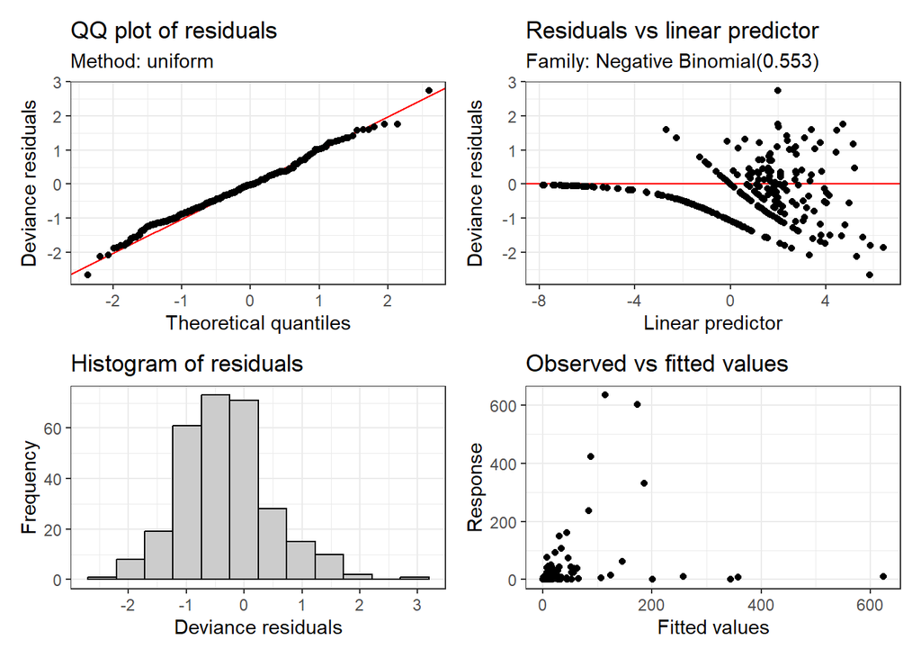

Тут не все супер, к сожалению.

### Визуализация модели

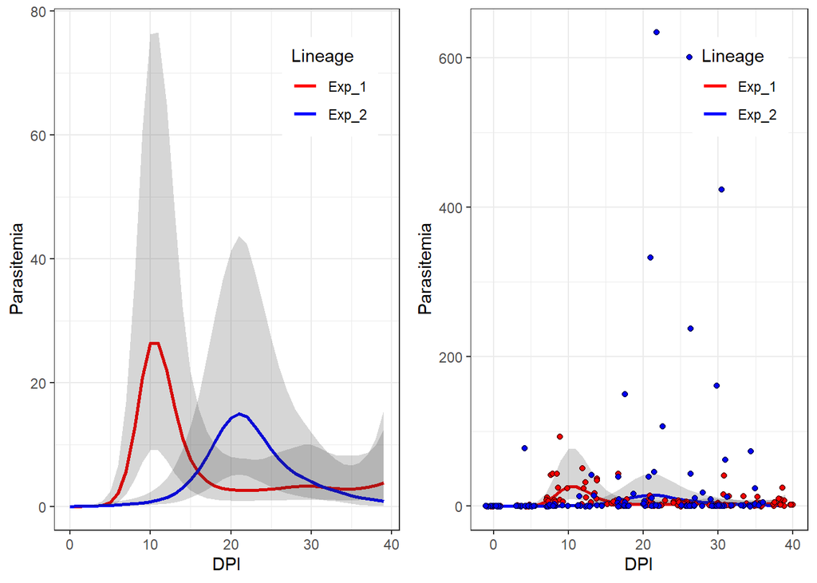

Здесь на левой картинке только модель, а на правой - еще и первичка.